# Project 2: Investigating Medical Appointment No-Shows in Brazil

- Introduction
- Data Wrangling
- Exploratory Data Analysis
- Conclusions

## Introduction

> This report analyzes a dataset of medical appointments in Brazil. In particular we will be looking trends amongst likelihood of patients who showed up for their scheduled appointments, and how they differed from patients who did not show up.

```python
# Importing libraries and raw dataset
import numpy as np
import pandas as pd
import matplotlib.pyplot as plt
import seaborn as sns
%matplotlib inline
```

## Data Wrangling

### General Properties

```python
#Loading dataset

df = pd.read_csv("noshowappointments-kagglev2-may-2016.csv")
df.head()
```

|  | PatientId | AppointmentID | Gender | ScheduledDay | AppointmentDay | Age | Neighbourhood | Scholarship | Hipertension | Diabetes | Alcoholism | Handcap | SMS_received | No-show |
| --- | --- | --- | --- | --- | --- | --- | --- | --- | --- | --- | --- | --- | --- | --- |
| 0 | 2.987250e+13 | 5642903 | F | 2016-04-29T18:38:08Z | 2016-04-29T00:00:00Z | 62 | JARDIM DA PENHA | 0 | 1 | 0 | 0 | 0 | 0 | No |
| 1 | 5.589978e+14 | 5642503 | M | 2016-04-29T16:08:27Z | 2016-04-29T00:00:00Z | 56 | JARDIM DA PENHA | 0 | 0 | 0 | 0 | 0 | 0 | No |
| 2 | 4.262962e+12 | 5642549 | F | 2016-04-29T16:19:04Z | 2016-04-29T00:00:00Z | 62 | MATA DA PRAIA | 0 | 0 | 0 | 0 | 0 | 0 | No |
| 3 | 8.679512e+11 | 5642828 | F | 2016-04-29T17:29:31Z | 2016-04-29T00:00:00Z | 8 | PONTAL DE CAMBURI | 0 | 0 | 0 | 0 | 0 | 0 | No |
| 4 | 8.841186e+12 | 5642494 | F | 2016-04-29T16:07:23Z | 2016-04-29T00:00:00Z | 56 | JARDIM DA PENHA | 0 | 1 | 1 | 0 | 0 | 0 | No |

```python
df.info()
```

```
<class 'pandas.core.frame.DataFrame'>
RangeIndex: 110527 entries, 0 to 110526
Data columns (total 14 columns):
 #   Column          Non-Null Count   Dtype
---  ------          --------------   -----
 0   PatientId       110527 non-null  float64
 1   AppointmentID   110527 non-null  int64
 2   Gender          110527 non-null  object
 3   ScheduledDay    110527 non-null  object
 4   AppointmentDay  110527 non-null  object
 5   Age             110527 non-null  int64
 6   Neighbourhood   110527 non-null  object
 7   Scholarship     110527 non-null  int64
 8   Hipertension    110527 non-null  int64
 9   Diabetes        110527 non-null  int64
 10  Alcoholism      110527 non-null  int64
 11  Handcap         110527 non-null  int64
 12  SMS_received    110527 non-null  int64
 13  No-show         110527 non-null  object
dtypes: float64(1), int64(8), object(5)
memory usage: 11.8+ MB
```

```python
df.describe()
```

|  | PatientId | AppointmentID | Age | Scholarship | Hipertension | Diabetes | Alcoholism | Handcap | SMS_received |
| --- | --- | --- | --- | --- | --- | --- | --- | --- | --- |
| count | 1.105270e+05 | 1.105270e+05 | 110527.000000 | 110527.000000 | 110527.000000 | 110527.000000 | 110527.000000 | 110527.000000 | 110527.000000 |
| mean | 1.474963e+14 | 5.675305e+06 | 37.088874 | 0.098266 | 0.197246 | 0.071865 | 0.030400 | 0.022248 | 0.321026 |
| std | 2.560949e+14 | 7.129575e+04 | 23.110205 | 0.297675 | 0.397921 | 0.258265 | 0.171686 | 0.161543 | 0.466873 |
| min | 3.921784e+04 | 5.030230e+06 | -1.000000 | 0.000000 | 0.000000 | 0.000000 | 0.000000 | 0.000000 | 0.000000 |
| 25% | 4.172614e+12 | 5.640286e+06 | 18.000000 | 0.000000 | 0.000000 | 0.000000 | 0.000000 | 0.000000 | 0.000000 |
| 50% | 3.173184e+13 | 5.680573e+06 | 37.000000 | 0.000000 | 0.000000 | 0.000000 | 0.000000 | 0.000000 | 0.000000 |
| 75% | 9.439172e+13 | 5.725524e+06 | 55.000000 | 0.000000 | 0.000000 | 0.000000 | 0.000000 | 0.000000 | 1.000000 |
| max | 9.999816e+14 | 5.790484e+06 | 115.000000 | 1.000000 | 1.000000 | 1.000000 | 1.000000 | 4.000000 | 1.000000 |

```python
sum(df.duplicated())
```

```
0
```

```python
df.shape
```

```
(110527, 14)
```

### Step 1: Calculating difference between the day the appointment day and scheduled day.

One key variable to which will likely differ between patient who show up is the time between the appointments. The following data cleaning calculates the difference between the two, and adds a "DaysDifference" column, and a "DayDiffBin" column to classify the time frames

```python
#Creating column to which calculated the difference between the appointment day and the day the appointment is scheduled.
#Converting "ScheduledDay" and "AppointmentDay" columns to datetime format

df['ScheduledDay'] = pd.to_datetime(df['ScheduledDay'])
df['AppointmentDay'] = pd.to_datetime(df['AppointmentDay'])

# Calculating difference between appointment day and scheduled day, rounding to "days" and converting it to dtype float for further analysis
DaysDifference = (df['AppointmentDay'] - df['ScheduledDay'])
DaysDifferenceFloat = (DaysDifference.dt.round('d'))
df["DaysDifference"] = DaysDifferenceFloat
df["DaysDifference"] = df["DaysDifference"].dt.days.astype(float)
df.info()
```

```
<class 'pandas.core.frame.DataFrame'>
RangeIndex: 110527 entries, 0 to 110526
Data columns (total 15 columns):
 #   Column          Non-Null Count   Dtype
---  ------          --------------   -----
 0   PatientId       110527 non-null  float64
 1   AppointmentID   110527 non-null  int64
 2   Gender          110527 non-null  object
 3   ScheduledDay    110527 non-null  datetime64[ns, UTC]
 4   AppointmentDay  110527 non-null  datetime64[ns, UTC]
 5   Age             110527 non-null  int64
 6   Neighbourhood   110527 non-null  object
 7   Scholarship     110527 non-null  int64
 8   Hipertension    110527 non-null  int64
 9   Diabetes        110527 non-null  int64
 10  Alcoholism      110527 non-null  int64
 11  Handcap         110527 non-null  int64
 12  SMS_received    110527 non-null  int64
 13  No-show         110527 non-null  object
 14  DaysDifference  110527 non-null  float64
dtypes: datetime64[ns, UTC](2), float64(2), int64(8), object(3)
memory usage: 12.6+ MB
```

```python
# Around 10% of the days difference values were <0. Opted to drop values as remaining dataset is still farily large
mask = df.loc[df["DaysDifference"] < 0 ].index
df.drop(mask, inplace = True)
```

```python
#Creating bin edges and bin names for difference
#Bin edges chosen were 0 to 15 days (half a month, 15 to 30 days (1 month), 30 days to 90 days (3 months), and > 90 days
bin_edges = [0,15,30,90,179]
bin_names = ["0 to 15 days","15 to 30 days","30 to 90 days","> 90 days "]
```

```python
#Creating DayDiffBin column
df['DayDiffBin'] = pd.cut(df['DaysDifference'],bin_edges, labels = bin_names, include_lowest = True)
```

```python
#Checking creation of column
df.head()
```

|  | PatientId | AppointmentID | Gender | ScheduledDay | AppointmentDay | Age | Neighbourhood | Scholarship | Hipertension | Diabetes | Alcoholism | Handcap | SMS_received | No-show | DaysDifference | DayDiffBin |
| --- | --- | --- | --- | --- | --- | --- | --- | --- | --- | --- | --- | --- | --- | --- | --- | --- |
| 5 | 9.598513e+13 | 5626772 | F | 2016-04-27 08:36:51+00:00 | 2016-04-29 00:00:00+00:00 | 76 | REPÚBLICA | 0 | 1 | 0 | 0 | 0 | 0 | No | 2.0 | 0 to 15 days |
| 6 | 7.336882e+14 | 5630279 | F | 2016-04-27 15:05:12+00:00 | 2016-04-29 00:00:00+00:00 | 23 | GOIABEIRAS | 0 | 0 | 0 | 0 | 0 | 0 | Yes | 1.0 | 0 to 15 days |
| 7 | 3.449833e+12 | 5630575 | F | 2016-04-27 15:39:58+00:00 | 2016-04-29 00:00:00+00:00 | 39 | GOIABEIRAS | 0 | 0 | 0 | 0 | 0 | 0 | Yes | 1.0 | 0 to 15 days |
| 8 | 5.639473e+13 | 5638447 | F | 2016-04-29 08:02:16+00:00 | 2016-04-29 00:00:00+00:00 | 21 | ANDORINHAS | 0 | 0 | 0 | 0 | 0 | 0 | No | 0.0 | 0 to 15 days |
| 9 | 7.812456e+13 | 5629123 | F | 2016-04-27 12:48:25+00:00 | 2016-04-29 00:00:00+00:00 | 19 | CONQUISTA | 0 | 0 | 0 | 0 | 0 | 0 | No | 1.0 | 0 to 15 days |

### Step 2: Converting "No Show" Column for easier analysis and more intuitive understanding.

```python
# Replacing "No" with "1", "Yes" with "0"
df["No-show"].replace({"No": 1, "Yes": 0}, inplace = True)
```

```python
# Renaming "No-show" column
df.rename(columns = {"No-show" : "TurnedUp"}, inplace = True)
df.head()
```

|  | PatientId | AppointmentID | Gender | ScheduledDay | AppointmentDay | Age | Neighbourhood | Scholarship | Hipertension | Diabetes | Alcoholism | Handcap | SMS_received | TurnedUp | DaysDifference | DayDiffBin |
| --- | --- | --- | --- | --- | --- | --- | --- | --- | --- | --- | --- | --- | --- | --- | --- | --- |
| 5 | 9.598513e+13 | 5626772 | F | 2016-04-27 08:36:51+00:00 | 2016-04-29 00:00:00+00:00 | 76 | REPÚBLICA | 0 | 1 | 0 | 0 | 0 | 0 | 1 | 2.0 | 0 to 15 days |
| 6 | 7.336882e+14 | 5630279 | F | 2016-04-27 15:05:12+00:00 | 2016-04-29 00:00:00+00:00 | 23 | GOIABEIRAS | 0 | 0 | 0 | 0 | 0 | 0 | 0 | 1.0 | 0 to 15 days |
| 7 | 3.449833e+12 | 5630575 | F | 2016-04-27 15:39:58+00:00 | 2016-04-29 00:00:00+00:00 | 39 | GOIABEIRAS | 0 | 0 | 0 | 0 | 0 | 0 | 0 | 1.0 | 0 to 15 days |
| 8 | 5.639473e+13 | 5638447 | F | 2016-04-29 08:02:16+00:00 | 2016-04-29 00:00:00+00:00 | 21 | ANDORINHAS | 0 | 0 | 0 | 0 | 0 | 0 | 1 | 0.0 | 0 to 15 days |
| 9 | 7.812456e+13 | 5629123 | F | 2016-04-27 12:48:25+00:00 | 2016-04-29 00:00:00+00:00 | 19 | CONQUISTA | 0 | 0 | 0 | 0 | 0 | 0 | 1 | 1.0 | 0 to 15 days |

```python
#Creating masks for easy reference between the group who turned up and the group who did not

df_turnedup = df[df["TurnedUp"] == 1]
df_noshow = df[df["TurnedUp"] == 0]

df_turnedup.TurnedUp.count()
# df_noshow
```

```
76646
```

## Exploratory Data Analysis

### Research Question 1: What is the percentage of no-shows?

```python
df["TurnedUp"].mean()
```

```
0.7791919972348169
```

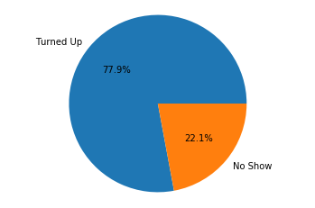

```python
#Pie chart showing split of appointments where patients have showed up or were a no-show

TotalShowedUp = df_turnedup.TurnedUp.count()
TotalNoShow = df_noshow.TurnedUp.count()

labels = "Turned Up", "No Show"
sizes = [TotalShowedUp,TotalNoShow]

fig1,ax1 = plt.subplots()
ax1.pie(sizes, labels = labels, autopct = '%1.1f%%')

ax1.axis('equal');
```

### Research Question 2: Which neighbourhoods have the highest and lowest rate of turning up?

Prelim analysis shows that the following neighbourhoods have the lowest rate of turning up:

1. ILHAS OCEÂNICAS DE TRINDADE
2. SANTOS DUMONT
3. SANTA CECÍLIA
4. SANTA CLARA
5. ITARARÉ

While the following neighbourhoods have the higher rate of turning up:

1. PARQUE INDUSTRIAL
2. ILHA DO BOI
3. AEROPORTO
4. SOLON BORGES
5. DO CABRAL

```python
df.groupby("Neighbourhood").TurnedUp.mean().sort_values(ascending = True)
```

```
Neighbourhood
ILHAS OCEÂNICAS DE TRINDADE    0.000000
SANTOS DUMONT                  0.698291
SANTA CECÍLIA                  0.701235
SANTA CLARA                    0.716418
ITARARÉ                        0.721387
                                 ...
DO CABRAL                      0.832645
SOLON BORGES                   0.835351
AEROPORTO                      0.875000
ILHA DO BOI                    0.903226
PARQUE INDUSTRIAL              1.000000
Name: TurnedUp, Length: 81, dtype: float64
```

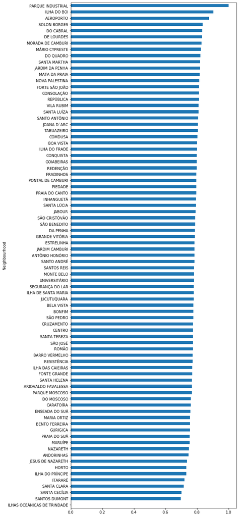

```python
df.groupby("Neighbourhood").TurnedUp.mean().sort_values(ascending = True).plot.barh(figsize = (8,25));
```

On closer inspection, the turn up rate is skewed for some neighbourhoods as they have very few appointments (e.g. ILHAS OCEÂNICAS DE TRINDADE only have 2 appointments, while PARQUE INDUSTRIAL which has as a 100% rate of turning up, has only 1 appointment)

```python
df["Neighbourhood"].value_counts().sort_values(ascending = True)
```

```
PARQUE INDUSTRIAL                 1
ILHAS OCEÂNICAS DE TRINDADE       2
AEROPORTO                         8
ILHA DO FRADE                    10
ILHA DO BOI                      31
                               ...
ITARARÉ                        3259
JARDIM DA PENHA                3426
RESISTÊNCIA                    3906
MARIA ORTIZ                    4872
JARDIM CAMBURI                 6587
Name: Neighbourhood, Length: 81, dtype: int64
```

The next section excludes neighbourhoods with less than 50 appointments to reduce the effects of the small sample size in specific neighbourhoods

```python
#Generating list of neighbourhoods with >50 datapoints
threshold = 50
NeighbourhoodCount = df["Neighbourhood"].value_counts()
to_include = NeighbourhoodCount[NeighbourhoodCount > threshold].index

to_include
```

```
Index(['JARDIM CAMBURI', 'MARIA ORTIZ', 'RESISTÊNCIA', 'JARDIM DA PENHA',
       'ITARARÉ', 'CENTRO', 'TABUAZEIRO', 'SANTA MARTHA', 'JESUS DE NAZARETH',
       'BONFIM', 'CARATOÍRA', 'SANTO ANTÔNIO', 'SANTO ANDRÉ', 'SÃO PEDRO',
       'JABOUR', 'NOVA PALESTINA', 'ROMÃO', 'ANDORINHAS', 'DA PENHA',
       'ILHA DO PRÍNCIPE', 'SÃO JOSÉ', 'GURIGICA', 'FORTE SÃO JOÃO',
       'SÃO CRISTÓVÃO', 'MARUÍPE', 'ILHA DE SANTA MARIA', 'BELA VISTA',
       'REDENÇÃO', 'CRUZAMENTO', 'SÃO BENEDITO', 'JOANA D´ARC', 'CONSOLAÇÃO',
       'PRAIA DO SUÁ', 'SANTOS DUMONT', 'SANTA TEREZA', 'GRANDE VITÓRIA',
       'INHANGUETÁ', 'ILHA DAS CAIEIRAS', 'PRAIA DO CANTO', 'BENTO FERREIRA',
       'CONQUISTA', 'REPÚBLICA', 'MONTE BELO', 'VILA RUBIM', 'PARQUE MOSCOSO',
       'DO QUADRO', 'GOIABEIRAS', 'FONTE GRANDE', 'JUCUTUQUARA',
       'MATA DA PRAIA', 'SANTOS REIS', 'DO CABRAL', 'ESTRELINHA',
       'SANTA CLARA', 'PIEDADE', 'SOLON BORGES', 'SANTA CECÍLIA', 'DO MOSCOSO',
       'SANTA LÚCIA', 'SANTA LUÍZA', 'BARRO VERMELHO', 'BOA VISTA', 'COMDUSA',
       'MÁRIO CYPRESTE', 'DE LOURDES', 'ARIOVALDO FAVALESSA', 'FRADINHOS',
       'ANTÔNIO HONÓRIO', 'ENSEADA DO SUÁ', 'SANTA HELENA', 'HORTO',
       'UNIVERSITÁRIO', 'SEGURANÇA DO LAR', 'NAZARETH', 'MORADA DE CAMBURI',
       'PONTAL DE CAMBURI'],
      dtype='object')
```

```python
#Creating new dataframe with only neighbourhoods with >50 datapoints
df_included = df.loc[df["Neighbourhood"].isin(to_include)]
```

```python
df_included.groupby("Neighbourhood").TurnedUp.mean().sort_values(ascending = True)
```

```
Neighbourhood
SANTOS DUMONT        0.698291
SANTA CECÍLIA        0.701235
SANTA CLARA          0.716418
ITARARÉ              0.721387
ILHA DO PRÍNCIPE     0.732161
                       ...
MÁRIO CYPRESTE       0.824561
MORADA DE CAMBURI    0.827957
DE LOURDES           0.832117
DO CABRAL            0.832645
SOLON BORGES         0.835351
Name: TurnedUp, Length: 76, dtype: float64
```

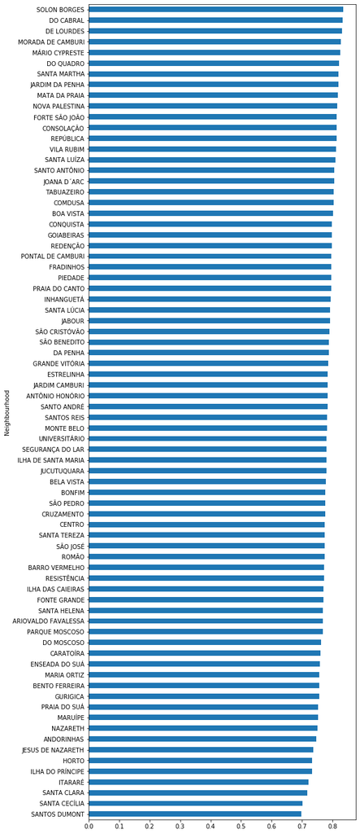

```python
df_included.groupby("Neighbourhood").TurnedUp.mean().sort_values(ascending = True).plot.barh(figsize = (8,25));
```

After excluding neighbourhoods with too few datapoints, the following neighbourhoods have the lowest rate of turning up:

1. SANTOS DUMONT
2. SANTA CECÍLIA
3. SANTA CLARA
4. ITARARÉ
5. ILHA DO PRÍNCIPE

While the following have the highest rate of turning up:

1. SOLON BORGES
2. DO CABRAL
3. DE LOURDES
4. MORADA DE CAMBURI
5. MÁRIO CYPRESTE

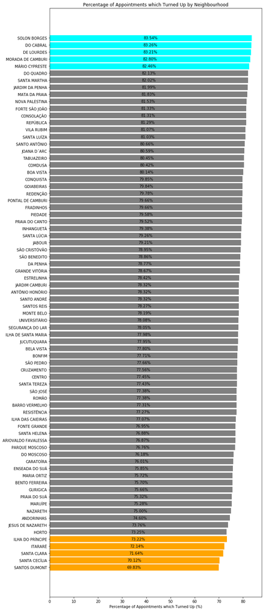

```python
# Setting up data for horizontal bar chart

neighbourhood_mean = (100*(df_included.groupby("Neighbourhood").TurnedUp.mean().sort_values(ascending = True))).round(4)
neighbourhood_labels = neighbourhood_mean.index
# neighbourhood_mean

# Chart parameters
y = np.arange(len(neighbourhood_labels))*1  # the label locations
height = 0.2  # the width of the bars

fig2, ax2 = plt.subplots(figsize = (10,23))
neighbourhood_bar = ax2.barh(y, neighbourhood_mean, color = ['gray'])
neighbourhood_bar[0].set_color('orange')
neighbourhood_bar[1].set_color('orange')
neighbourhood_bar[2].set_color('orange')
neighbourhood_bar[3].set_color('orange')
neighbourhood_bar[4].set_color('orange')


neighbourhood_bar[-1].set_color('cyan')
neighbourhood_bar[-2].set_color('cyan')
neighbourhood_bar[-3].set_color('cyan')
neighbourhood_bar[-4].set_color('cyan')
neighbourhood_bar[-5].set_color('cyan')

# #Adding labels

ax2.set_xlabel("Percentage of Appointments which Turned Up (%)");
ax2.set_title("Percentage of Appointments which Turned Up by Neighbourhood")
ax2.set_yticks(y)
ax2.set_yticklabels(neighbourhood_labels)

def autolabel_ax2(rects):
    for rect in rects:
        width, height = rect.get_width(), rect.get_height()
        x , y = rect.get_xy()
        ax2.annotate('{:.2f}%'.format(width),
                    xy = (x + width / 2, y + height/2),
                    ha='center', va='center',
                    )

autolabel_ax2(neighbourhood_bar)
fig2.tight_layout()
```

### Research Question 3: Is a greater difference in between the scheduled day and appointment day associated with a higher rate of no shows?

A higher difference between the scheduled day and appointment day is associated with a higher rate of no shows, except for the >90 days group which has a lower rate of no shows than the 15 to 30 days group, and the 30 days to 90 days group.

```python
df.groupby("DayDiffBin")["TurnedUp"].mean().round(2)
```

```
DayDiffBin
0 to 15 days     0.82
15 to 30 days    0.68
30 to 90 days    0.67
> 90 days        0.73
Name: TurnedUp, dtype: float64
```

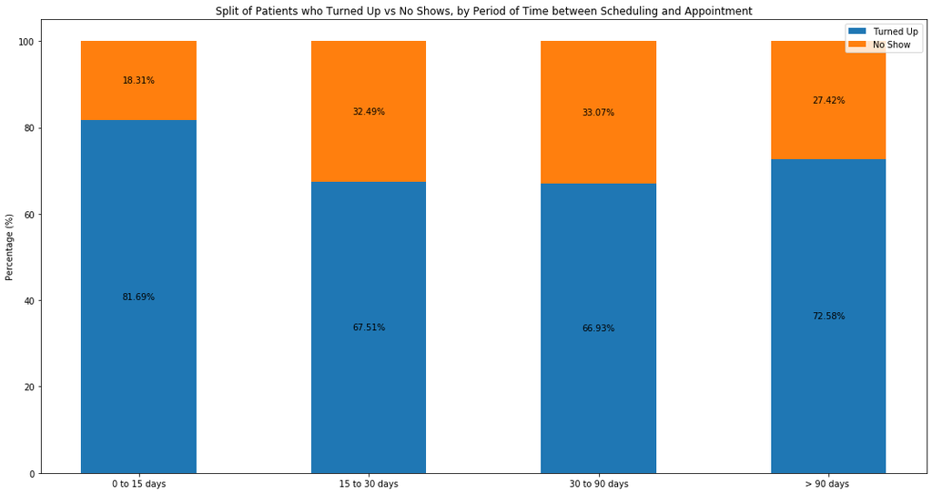

```python
# Setting up data for stacked bar plot

DayLabels = bin_names
TurnedUp_mean = (100*(df.groupby("DayDiffBin")["TurnedUp"].mean())).round(2)
NoShow_mean = (100*(1 - df.groupby("DayDiffBin")["TurnedUp"].mean())).round(2)

# Plot parameters
x = 1 * (np.arange(len(TurnedUp_mean)))
width = 0.5

fig3, ax3 = plt.subplots(figsize = (15,8))

TurnedUp_bar = ax3.bar(x, TurnedUp_mean, width=width, label = "Turned Up")
NoShow_bar = ax3.bar(x, NoShow_mean, width=width, label = "No Show", bottom =TurnedUp_mean)

#Adding labels

ax3.set_ylabel("Percentage (%)");
ax3.set_title("Split of Patients who Turned Up vs No Shows, by Period of Time between Scheduling and Appointment")
ax3.set_xticks(x)
ax3.set_xticklabels(DayLabels)
ax3.legend( loc = 1)


def autolabel_ax3(rects):
    for rect in rects:
        width, height = rect.get_width(), rect.get_height()
        x , y = rect.get_xy()
        ax3.annotate('{:.2f}%'.format(height),
                    xy = (x + width / 2, y + height/2),
                    ha='center', va='center',
                    )


autolabel_ax3(TurnedUp_bar)
autolabel_ax3(NoShow_bar)
fig3.tight_layout()
```

### Research Question 4: Is receiving a SMS reminder associated with a higher rate of turning up?

Counterintuitively, it seems as it more of those who did not receive an SMS turned up for their appointments.

```python
# Checking whether more of those who received an SMS turned up
df.groupby("SMS_received")["TurnedUp"].mean()
```

```
SMS_received
0    0.810190
1    0.724255
Name: TurnedUp, dtype: float64
```

The higher rate of turning up for those who did not receive an SMS could be due to the appointments with short period between the day they made the appointment and the appointment itself not being sent an SMS (e.g. appointments made on the same day of the appointment would not need an SMS reminder). This is especially important as there is a large number of patients who have a "DaysDifference" of 0

```python
# Checking if there is a difference in their rate of turning up based on
# the difference between their scheduled and appointment day, and whether they received an SMS
df.groupby(["DayDiffBin", "SMS_received"])["TurnedUp"].mean()
```

```
DayDiffBin     SMS_received
0 to 15 days   0               0.844726
               1               0.742344
15 to 30 days  0               0.630981
               1               0.704291
30 to 90 days  0               0.623636
               1               0.697251
> 90 days      0               0.764706
               1               0.703390
Name: TurnedUp, dtype: float64
```

```python
#Checking the min "DaysDifference" for those who received an SMS reminder

df_SMS = df[(df["SMS_received"] == 1)]
df_SMS.describe()
```

|  | PatientId | AppointmentID | Age | Scholarship | Hipertension | Diabetes | Alcoholism | Handcap | SMS_received | TurnedUp | DaysDifference |
| --- | --- | --- | --- | --- | --- | --- | --- | --- | --- | --- | --- |
| count | 3.548200e+04 | 3.548200e+04 | 35482.000000 | 35482.000000 | 35482.000000 | 35482.000000 | 35482.000000 | 35482.000000 | 35482.0 | 35482.000000 | 35482.000000 |
| mean | 1.438652e+14 | 5.648697e+06 | 37.513810 | 0.098782 | 0.193619 | 0.066400 | 0.023871 | 0.016572 | 1.0 | 0.724255 | 18.605067 |
| std | 2.518491e+14 | 8.066133e+04 | 22.330332 | 0.298374 | 0.395140 | 0.248983 | 0.152650 | 0.139882 | 0.0 | 0.446895 | 16.975885 |
| min | 5.376153e+05 | 5.030230e+06 | 0.000000 | 0.000000 | 0.000000 | 0.000000 | 0.000000 | 0.000000 | 1.0 | 0.000000 | 2.000000 |
| 25% | 3.932647e+12 | 5.605518e+06 | 19.000000 | 0.000000 | 0.000000 | 0.000000 | 0.000000 | 0.000000 | 1.0 | 0.000000 | 6.000000 |
| 50% | 2.982433e+13 | 5.648944e+06 | 37.000000 | 0.000000 | 0.000000 | 0.000000 | 0.000000 | 0.000000 | 1.0 | 1.000000 | 14.000000 |
| 75% | 9.358590e+13 | 5.716710e+06 | 55.000000 | 0.000000 | 0.000000 | 0.000000 | 0.000000 | 0.000000 | 1.0 | 1.000000 | 27.000000 |
| max | 9.999320e+14 | 5.773092e+06 | 115.000000 | 1.000000 | 1.000000 | 1.000000 | 1.000000 | 4.000000 | 1.0 | 1.000000 | 179.000000 |

```python
# There were no paitents who had a "DaysDifference" of < 2 who received an SMS.
# As such, the analysis will exclude patients who had a "DaysDifference" of < 2

df_waiting = df[df["DaysDifference"] >= 2]
df_waiting.groupby(["DayDiffBin", "SMS_received"])["TurnedUp"].mean()
```

```
DayDiffBin     SMS_received
0 to 15 days   0               0.717195
               1               0.742344
15 to 30 days  0               0.630981
               1               0.704291
30 to 90 days  0               0.623636
               1               0.697251
> 90 days      0               0.764706
               1               0.703390
Name: TurnedUp, dtype: float64
```

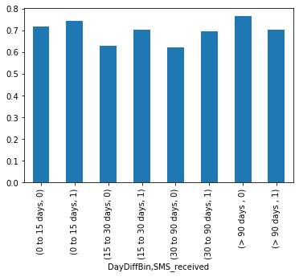

```python
df_waiting.groupby(["DayDiffBin", "SMS_received"])["TurnedUp"].mean().plot(kind = "bar");
```

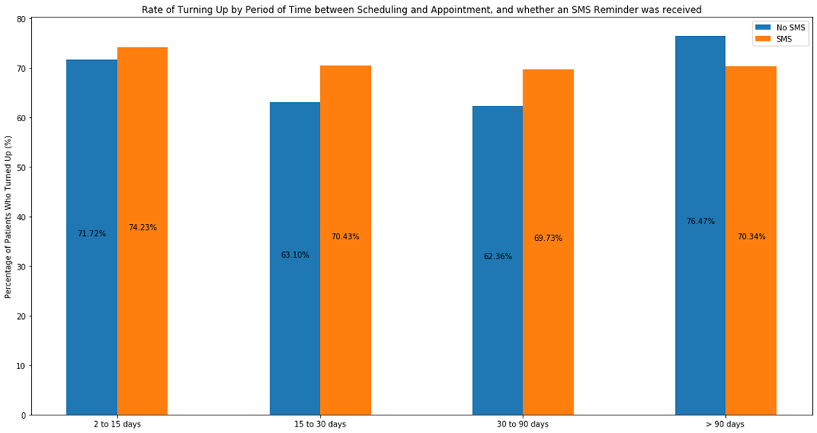

```python
#Creating data for matplotlib bar chart

DayLabels = ["2 to 15 days","15 to 30 days","30 to 90 days","> 90 days "]
NoSMS_mean = (100*(df_waiting[df["SMS_received"] == 0].groupby(["DayDiffBin"])["TurnedUp"].mean())).round(2)
SMS_mean = (100*df_waiting[df["SMS_received"] == 1].groupby(["DayDiffBin"])["TurnedUp"].mean()).round(2)


# Chart Parameters
x = np.arange(len(DayLabels))*2  # the label locations
width = 0.5  # the width of the bars

fig4, ax4 = plt.subplots(figsize = (15,8))
NoSMS_rect = ax4.bar(x - width/2, NoSMS_mean, width = width, label = "No SMS")
SMS_rect = ax4.bar(x + width/2, SMS_mean, width = width, label = "SMS")

# #Adding labels

ax4.set_ylabel("Percentage of Patients Who Turned Up (%)");
ax4.set_title("Rate of Turning Up by Period of Time between Scheduling and Appointment, and whether an SMS Reminder was received")
ax4.set_xticks(x)
ax4.set_xticklabels(DayLabels)
ax4.legend()


def autolabel_ax4(rects):

    for rect in rects:
        width, height = rect.get_width(), rect.get_height()
        x, y = rect.get_x(), rect.get_y()
        ax4.annotate('{:.2f}%'.format(height),
                    xy= (x + width/2 , y + height/2),
                    ha='center', va='bottom'
                    )

autolabel_ax4(NoSMS_rect)
autolabel_ax4(SMS_rect)
fig4.tight_layout()
```

## Conclusions

In this analysis we posed 4 research questions :

1. What is the percentage of no-shows?
2. Which neighbourhoods have the highest and lowest rate of turning up?
3. Is a greater difference in between the scheduled day and appointment day associated with a higher rate of no shows?
4. Is receiving a SMS reminder associated with a higher rate of turning up?

### 1. What is the percentage of no-shows?

We found that around 78% of appointments showed up

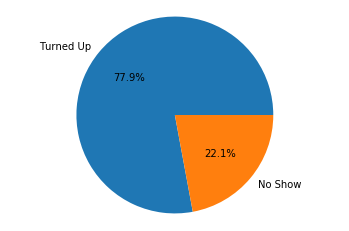

```python
fig1
```

### 2. Which neighbourhoods have the highest and lowest rate of turning up?

After excluding neighbourhoods with too few datapoints, the following neighbourhoods have the lowest rate of turning up. Patients from these neighbourhoods could be studied further to understand if there are any underlying or systemic factors that affect their ability to turn up and thus develop appropriate assistance or interventions for this group:

1. SANTOS DUMONT
2. SANTA CECÍLIA
3. SANTA CLARA
4. ITARARÉ
5. ILHA DO PRÍNCIPE

The following have the highest rate of turning up. This group could be studied further to see if there any commonalities/best practices which could be adopted for the former group:

1. SOLON BORGES
2. DO CABRAL
3. DE LOURDES
4. MORADA DE CAMBURI
5. MÁRIO CYPRESTE

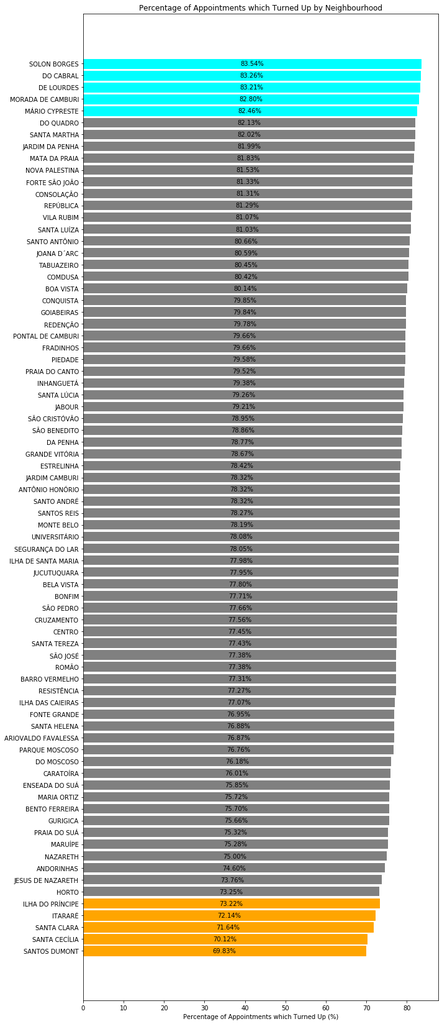

```python
fig2
```

### 3. Is a greater difference in between the scheduled day and appointment day associated with a higher rate of no shows?

Except for appointments which were scheduled >90 days before the appointment date, a greater difference between the scheduled day and appointment day is associated with a higher rate of no shows with the 0 to 15 day group have the least no shows at 18.3%, followed by the 15 to 30 day group at 32.5% and 30 to 90 day group at 33.1%

The >90 day group had 27.4% rate of no shows, lower rate than the 15 to 30 day and 30 to 90 day groups. This could be for several reasons such as the type of appointment (e.g regular 6 month check ups vs appointments for ad-hoc conditions) and would warrant further investigation.

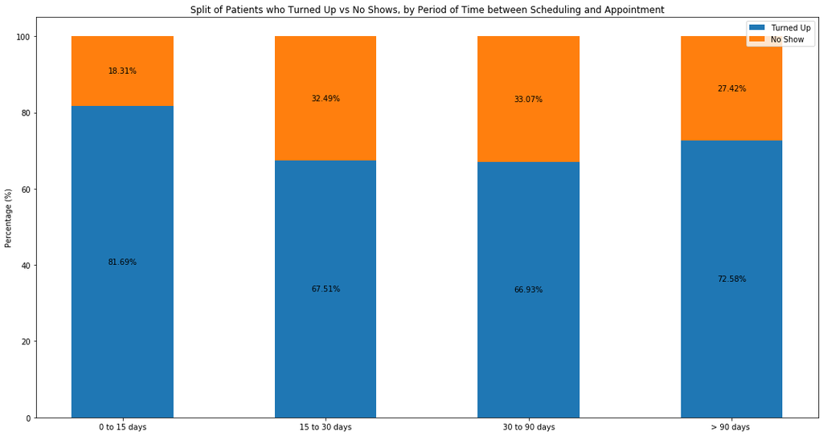

```python
fig3
```

### 4. Is receiving an SMS reminder associated with a higher rate of turning up?

For this analysis, we dropped cases which had < 2 days difference between the scheduled day and appointment day as these appointments did not receive an SMS reminder.

For all groups, except the > 90 days group, patients who received an SMS reminder turned up for their appointments at a higher rate, with the 15 to 30 day and 30 to 90 day group seeing ~7% higher turn up rate if they received a reminder. The effect was less pronounced for the 2 to 15 day group which had ~2.5% higher turn up rate for the group that received a reminder.

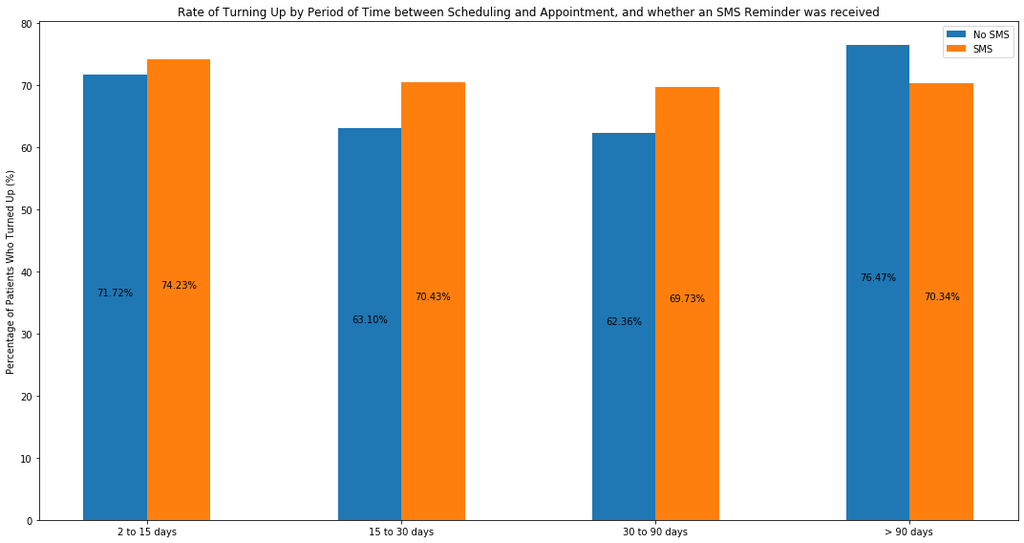

```python
fig4
```

```python
from subprocess import call
call(['python', '-m', 'nbconvert', 'Investigate_a_Dataset.ipynb'])
```

```
4294967295
```